```python
# Initialize Otter
import otter
grader = otter.Notebook("hw5.ipynb")
```

# CPSC 330 - Applied Machine Learning

## Homework 5: Putting it all together

### Associated lectures: All material till lecture 13

**Due date: Monday, October 28th, 2024 at 11:59pm**

0. Submission instructions
1. Understanding the problem
2. Data splitting
3. EDA
4. Feature engineering
5. Preprocessing and transformations
6. Baseline model
7. Linear models
8. Different models
9. Feature selection
10. Hyperparameter optimization
11. Interpretation and feature importances
12. Results on the test set
13. Summary of the results
14. Your takeaway from the course

## Submission instructions

rubric={points:4}

**You may work with a partner on this homework and submit your assignment as a group.** Below are some instructions on working as a group.

- The maximum group size is 2.
- Use group work as an opportunity to collaborate and learn new things from each other.
- Be respectful to each other and make sure you understand all the concepts in the assignment well.
- It's your responsibility to make sure that the assignment is submitted by one of the group members before the deadline.
- You can find the instructions on how to do group submission on Gradescope [here](https://help.gradescope.com/article/m5qz2xsnjy-student-add-group-members).
- If you would like to use late tokens for the homework, all group members must have the necessary late tokens available. Please note that the late tokens will be counted for all members of the group.

Follow the [homework submission instructions](https://github.com/UBC-CS/cpsc330-2024W1/blob/master/docs/homework_instructions.md).

1. Before submitting the assignment, run all cells in your notebook to make sure there are no errors by doing `Kernel -> Restart Kernel and Clear All Outputs` and then `Run -> Run All Cells`.
2. Notebooks with cell execution numbers out of order or not starting from "1" will have marks deducted. Notebooks without the output displayed may not be graded at all (because we need to see the output in order to grade your work).
3. Follow the [CPSC 330 homework instructions](https://ubc-cs.github.io/cpsc330-2024W1/docs/homework_instructions.html), which include information on how to do your assignment and how to submit your assignment.
4. Upload your solution on Gradescope. Check out this [Gradescope Student Guide](https://lthub.ubc.ca/guides/gradescope-student-guide/) if you need help with Gradescope submission.
5. Make sure that the plots and output are rendered properly in your submitted file. If the .ipynb file is too big and doesn't render on Gradescope, also upload a pdf or html in addition to the .ipynb so that the TAs can view your submission on Gradescope.

*Note: The assignments will get gradually more open-ended as we progress through the course. In many cases, there won't be a single correct solution. Sometimes you will have to make your own choices and your own decisions (for example, on what parameter values to use when they are not explicitly provided in the instructions). Use your own judgment in such cases and justify your choices, if necessary.*

## Imports

Imports

*Points:* 0

```python
...
import pandas as pd
import numpy as np
import matplotlib.pyplot as plt

from sklearn.model_selection import (
    GridSearchCV,
    cross_val_score,
    cross_validate,
    train_test_split,
)

import seaborn as sns   # for visualization
# here is the document for seaborn in python: https://seaborn.pydata.org/tutorial.html
```

## Introduction

In this homework you will be working on an open-ended mini-project, where you will put all the different things you have learned so far together to solve an interesting problem.

A few notes and tips when you work on this mini-project:

#### Tips

1. This mini-project is open-ended, and while working on it, there might be some situations where you'll have to use your own judgment and make your own decisions (as you would be doing when you work as a data scientist). Make sure you explain your decisions whenever necessary.
2. **Do not include everything you ever tried in your submission** -- it's fine just to have your final code. That said, your code should be reproducible and well-documented. For example, if you chose your hyperparameters based on some hyperparameter optimization experiment, you should leave in the code for that experiment so that someone else could re-run it and obtain the same hyperparameters, rather than mysteriously just setting the hyperparameters to some (carefully chosen) values in your code.
3. If you realize that you are repeating a lot of code try to organize it in functions. Clear presentation of your code, experiments, and results is the key to be successful in this lab. You may use code from lecture notes or previous lab solutions with appropriate attributions.

#### Assessment

We plan to grade fairly and leniently. We don't have some secret target score that you need to achieve to get a good grade. **You'll be assessed on demonstration of mastery of course topics, clear presentation, and the quality of your analysis and results.** For example, if you just have a bunch of code and no text or figures, that's not good. If you do a bunch of sane things and get a lower accuracy than your friend, don't sweat it.

#### A final note

Finally, this style of this "project" question is different from other assignments. It'll be up to you to decide when you're "done" -- in fact, this is one of the hardest parts of real projects. But please don't spend WAY too much time on this... perhaps "a few hours" (15-20 hours???) is a good guideline for this project . Of course if you're having fun you're welcome to spend as much time as you want! But, if so, try not to do it out of perfectionism or getting the best possible grade. Do it because you're learning and enjoying it. Students from the past cohorts have found such kind of labs useful and fun and I hope you enjoy it as well.

## 1. Pick your problem and explain the prediction problem

rubric={points:3}

In this mini project, you have the option to choose on which dataset you will be working on. The tasks you will need to carry on will be similar, independently of your choice.

### Option 1

You can choose to work on a classification problem of predicting whether a credit card client will default or not. For this problem, you will use [Default of Credit Card Clients Dataset](https://www.kaggle.com/uciml/default-of-credit-card-clients-dataset). In this data set, there are 30,000 examples and 24 features, and the goal is to estimate whether a person will default (fail to pay) their credit card bills; this column is labeled "default.payment.next.month" in the data. The rest of the columns can be used as features. You may take some ideas and compare your results with [the associated research paper](https://www.sciencedirect.com/science/article/pii/S0957417407006719), which is available through [the UBC library](https://www.library.ubc.ca/).

### Option 2

You can choose to work on a regression problem using a [dataset](https://www.kaggle.com/dgomonov/new-york-city-airbnb-open-data) of New York City Airbnb listings from 2019. As usual, you'll need to start by downloading the dataset, then you will try to predict `reviews_per_month`, as a proxy for the popularity of the listing. Airbnb could use this sort of model to predict how popular future listings might be before they are posted, perhaps to help guide hosts create more appealing listings. In reality they might instead use something like vacancy rate or average rating as their target, but we do not have that available here.

> Note there is an updated version of this dataset with more features available [here](http://insideairbnb.com/). The features were are using in `listings.csv.gz` for the New York city datasets. You will also see some other files like `reviews.csv.gz`. For your own interest you may want to explore the expanded dataset and try your analysis there. However, please submit your results on the dataset obtained from Kaggle.

**Your tasks:**

1. Spend some time understanding the options and pick the one you find more interesting (it may help spending some time looking at the documentation available on Kaggle for each dataset).
2. After making your choice, focus on understanding the problem and what each feature means, again using the documentation on the dataset page on Kaggle. Write a few sentences on your initial thoughts on the problem and the dataset.
3. Download the dataset and read it as a pandas dataframe.

Solution_1

*Points:* 3

I would like to pick the default of credit card clients dataset, to work on the classification problem of predicting whether a credit card client will default or not.

```python
...
credit_df = pd.read_csv("data/UCI_Credit_Card.csv", index_col=0)
credit_df.head()
```

| ID | LIMIT_BAL | SEX | EDUCATION | MARRIAGE | AGE | PAY_0 | PAY_2 | PAY_3 | PAY_4 | PAY_5 | ... | BILL_AMT4 | BILL_AMT5 | BILL_AMT6 | PAY_AMT1 | PAY_AMT2 | PAY_AMT3 | PAY_AMT4 | PAY_AMT5 | PAY_AMT6 | default.payment.next.month |
| --- | --- | --- | --- | --- | --- | --- | --- | --- | --- | --- | --- | --- | --- | --- | --- | --- | --- | --- | --- | --- | --- |
| 1 | 20000.0 | 2 | 2 | 1 | 24 | 2 | 2 | -1 | -1 | -2 | ... | 0.0 | 0.0 | 0.0 | 0.0 | 689.0 | 0.0 | 0.0 | 0.0 | 0.0 | 1 |
| 2 | 120000.0 | 2 | 2 | 2 | 26 | -1 | 2 | 0 | 0 | 0 | ... | 3272.0 | 3455.0 | 3261.0 | 0.0 | 1000.0 | 1000.0 | 1000.0 | 0.0 | 2000.0 | 1 |
| 3 | 90000.0 | 2 | 2 | 2 | 34 | 0 | 0 | 0 | 0 | 0 | ... | 14331.0 | 14948.0 | 15549.0 | 1518.0 | 1500.0 | 1000.0 | 1000.0 | 1000.0 | 5000.0 | 0 |
| 4 | 50000.0 | 2 | 2 | 1 | 37 | 0 | 0 | 0 | 0 | 0 | ... | 28314.0 | 28959.0 | 29547.0 | 2000.0 | 2019.0 | 1200.0 | 1100.0 | 1069.0 | 1000.0 | 0 |
| 5 | 50000.0 | 1 | 2 | 1 | 57 | -1 | 0 | -1 | 0 | 0 | ... | 20940.0 | 19146.0 | 19131.0 | 2000.0 | 36681.0 | 10000.0 | 9000.0 | 689.0 | 679.0 | 0 |

5 rows × 24 columns

## 2. Data splitting

rubric={points:2}

**Your tasks:**

1. Split the data into train (70%) and test (30%) portions with `random_state=123`.

> If your computer cannot handle training on 70% training data, make the test split bigger.

Solution_2

*Points:* 2

```python
...


train_df, test_df = train_test_split(
    credit_df,
    test_size=0.3,
    random_state=123)

X_train = train_df.drop(columns='default.payment.next.month')
y_train = train_df['default.payment.next.month']

X_test = test_df.drop(columns='default.payment.next.month')
y_test = test_df['default.payment.next.month']

print(X_train.head())
print(X_train.shape)
```

```
       LIMIT_BAL  SEX  EDUCATION  MARRIAGE  AGE  PAY_0  PAY_2  PAY_3  PAY_4  \
ID
16396   320000.0    2          1         2   36      0      0      0      0
21449   440000.0    2          1         2   30     -1     -1     -1      0
20035   160000.0    2          3         1   44     -2     -2     -2     -2
25756   120000.0    2          2         1   30      0      0      0      0
1439     50000.0    1          2         2   54      1      2      0      0

       PAY_5  ...  BILL_AMT3  BILL_AMT4  BILL_AMT5  BILL_AMT6  PAY_AMT1  \
ID            ...
16396      0  ...    28695.0    19370.0    10155.0     3788.0    5000.0
21449      0  ...    87426.0   171244.0   150897.0   117870.0     612.0
20035     -2  ...      -18.0      -18.0      -18.0      -18.0       0.0
25756      0  ...   104694.0   103058.0    71095.0    47379.0    3706.0
1439       0  ...    27168.0    27585.0    27910.0    27380.0       0.0

       PAY_AMT2  PAY_AMT3  PAY_AMT4  PAY_AMT5  PAY_AMT6
ID
16396    5018.0    1000.0    3000.0       0.0    7013.0
21449   87426.0  130007.0    3018.0   15000.0   51663.0
20035       0.0       0.0       0.0       0.0       0.0
25756    5502.0    4204.0    3017.0    2005.0    1702.0
1439     1400.0    1200.0    1500.0    1000.0    1500.0

[5 rows x 23 columns]
(21000, 23)
```

## 3. EDA

rubric={points:10}

**Your tasks:**

1. Perform exploratory data analysis on the train set.
2. Include at least two summary statistics and two visualizations that you find useful, and accompany each one with a sentence explaining it.
3. Summarize your initial observations about the data.
4. Pick appropriate metric/metrics for assessment.

Solution_3

*Points:* 10

```python
...
# set pandas to show all columns in the outputs:
pd.set_option('display.max_columns', None)

data_summary = train_df.describe()
data_summary
```

|  | LIMIT_BAL | SEX | EDUCATION | MARRIAGE | AGE | PAY_0 | PAY_2 | PAY_3 | PAY_4 | PAY_5 | PAY_6 | BILL_AMT1 | BILL_AMT2 | BILL_AMT3 | BILL_AMT4 | BILL_AMT5 | BILL_AMT6 | PAY_AMT1 | PAY_AMT2 | PAY_AMT3 | PAY_AMT4 | PAY_AMT5 | PAY_AMT6 | default.payment.next.month |
| --- | --- | --- | --- | --- | --- | --- | --- | --- | --- | --- | --- | --- | --- | --- | --- | --- | --- | --- | --- | --- | --- | --- | --- | --- |
| count | 21000.000000 | 21000.000000 | 21000.000000 | 21000.000000 | 21000.000000 | 21000.000000 | 21000.000000 | 21000.000000 | 21000.000000 | 21000.000000 | 21000.000000 | 21000.000000 | 21000.000000 | 21000.000000 | 21000.000000 | 21000.000000 | 21000.000000 | 21000.000000 | 2.100000e+04 | 21000.000000 | 21000.000000 | 21000.000000 | 21000.000000 | 21000.000000 |
| mean | 167880.651429 | 1.600762 | 1.852143 | 1.554000 | 35.500810 | -0.015429 | -0.137095 | -0.171619 | -0.225238 | -0.264429 | -0.295095 | 51107.566762 | 49126.824810 | 47010.414095 | 43486.610905 | 40428.518333 | 38767.202667 | 5673.585143 | 5.895027e+03 | 5311.432286 | 4774.021381 | 4751.850095 | 5237.762190 | 0.223238 |
| std | 130202.682167 | 0.489753 | 0.792961 | 0.521675 | 9.212644 | 1.120465 | 1.194506 | 1.196123 | 1.168556 | 1.137205 | 1.147992 | 73444.143025 | 71400.032096 | 69035.759516 | 64843.303993 | 61187.200817 | 59587.689549 | 17033.241454 | 2.180143e+04 | 18377.997079 | 15434.136142 | 15228.193125 | 18116.846563 | 0.416427 |
| min | 10000.000000 | 1.000000 | 0.000000 | 0.000000 | 21.000000 | -2.000000 | -2.000000 | -2.000000 | -2.000000 | -2.000000 | -2.000000 | -15308.000000 | -67526.000000 | -157264.000000 | -50616.000000 | -61372.000000 | -339603.000000 | 0.000000 | 0.000000e+00 | 0.000000 | 0.000000 | 0.000000 | 0.000000 | 0.000000 |
| 25% | 50000.000000 | 1.000000 | 1.000000 | 1.000000 | 28.000000 | -1.000000 | -1.000000 | -1.000000 | -1.000000 | -1.000000 | -1.000000 | 3649.250000 | 2925.750000 | 2663.750000 | 2293.750000 | 1739.500000 | 1215.750000 | 1000.000000 | 8.200000e+02 | 390.000000 | 266.000000 | 234.000000 | 110.750000 | 0.000000 |
| 50% | 140000.000000 | 2.000000 | 2.000000 | 2.000000 | 34.000000 | 0.000000 | 0.000000 | 0.000000 | 0.000000 | 0.000000 | 0.000000 | 22284.000000 | 21002.500000 | 20088.500000 | 19102.500000 | 18083.000000 | 16854.500000 | 2100.000000 | 2.007000e+03 | 1809.500000 | 1500.000000 | 1500.000000 | 1500.000000 | 0.000000 |
| 75% | 240000.000000 | 2.000000 | 2.000000 | 2.000000 | 41.000000 | 0.000000 | 0.000000 | 0.000000 | 0.000000 | 0.000000 | 0.000000 | 66979.750000 | 63795.250000 | 59895.000000 | 54763.250000 | 50491.000000 | 49253.750000 | 5007.250000 | 5.000000e+03 | 4628.500000 | 4021.250000 | 4016.000000 | 4000.000000 | 0.000000 |
| max | 1000000.000000 | 2.000000 | 6.000000 | 3.000000 | 79.000000 | 8.000000 | 8.000000 | 8.000000 | 8.000000 | 8.000000 | 8.000000 | 964511.000000 | 983931.000000 | 855086.000000 | 891586.000000 | 927171.000000 | 961664.000000 | 873552.000000 | 1.227082e+06 | 896040.000000 | 621000.000000 | 426529.000000 | 528666.000000 | 1.000000 |

Here we have some summary statistics. We can see there are no missing values in our training set. However, after taking a closer look at values in some columns, there are some 'unknown' categories. Since "unknown" does not really represent valid information, I will take these values as the missing values.

Also, we can find there are minima of 0 in the column EDUCATION and MARRIAGE, which in not explained in data document; and minima of -2 and maxima of 8 from the column PAY_0 up to the column PAY_6, which is inconsistent with the description of variables in the kaggle. Let's take PAY_0 as an example to see its values:

```python
train_df['PAY_0'].unique()
```

```
array([ 0, -1, -2,  1,  2,  3,  5,  8,  7,  4,  6], dtype=int64)
```

We can find there are -2, 0 in the columns and also missing 9 which is actually mentioned in the data description. We may need to deal with this problem later in the feature engineering and preprocessing part.

Let's take a look at the distributions of the variables SEX, LIMIT_BAL, EDUCATION, MARRIAGE, AGE, PAY_0, BILL_AMT1, PAY_AMT1:

(here I decide to take PAY_0, BILL_AMT1, PAY_AMT1 as examples to represent the distribution in these features on other months)

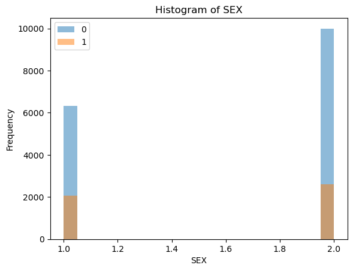

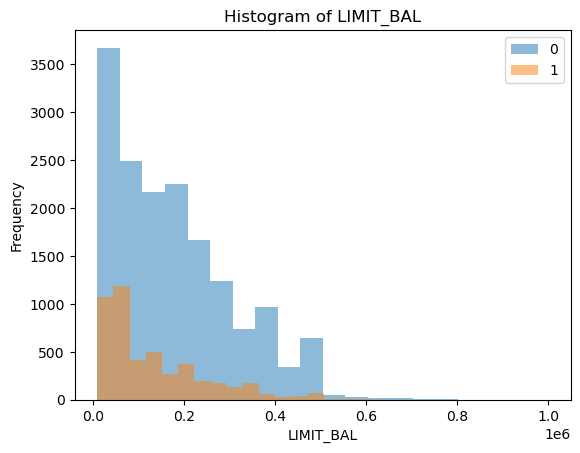

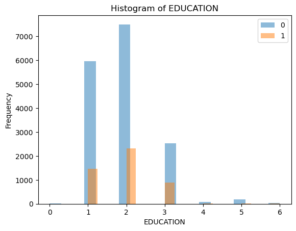

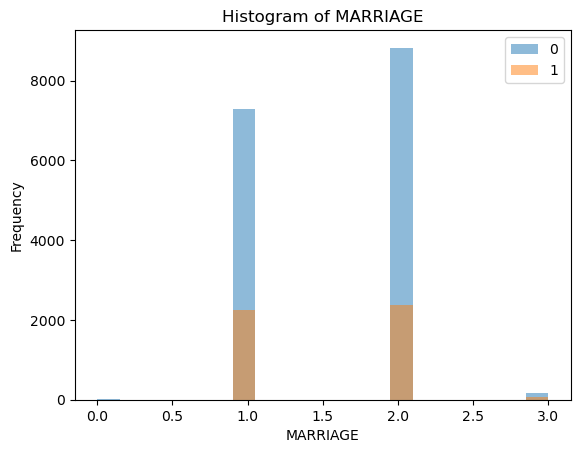

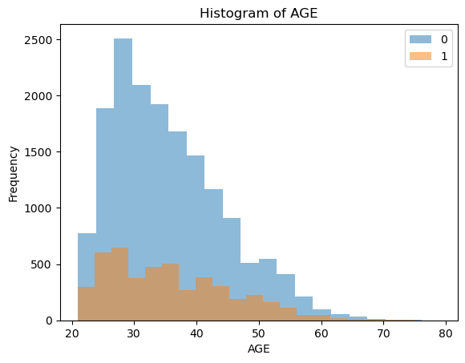

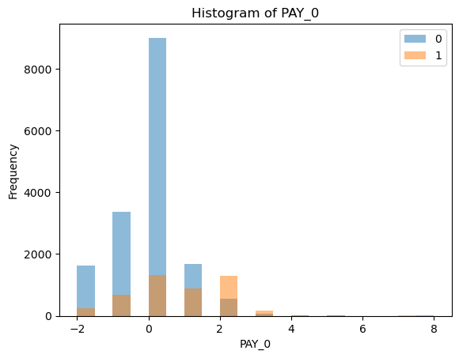

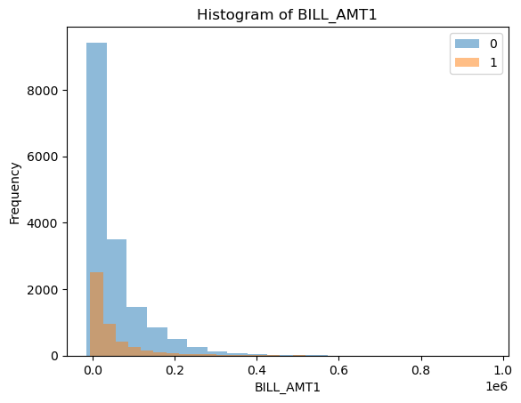

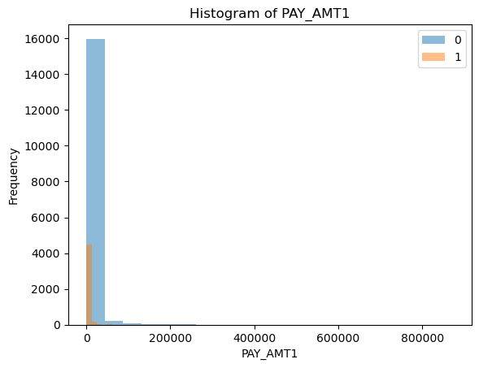

```python
...
for feat in ['SEX', 'LIMIT_BAL', 'EDUCATION', 'MARRIAGE', 'AGE', 'PAY_0', 'BILL_AMT1', 'PAY_AMT1']:
    train_df.groupby('default.payment.next.month')[feat].plot.hist(bins=20,alpha=0.5,legend=True,title="Histogram of "+feat)
    plt.xlabel(feat)
    plt.show()

# reference: HW3
```

From the histogram plots above, we can roughly see the distributions of most of these features show the differences between the two groups (default/non-default), except the BILL_AMT1 and PAY_AMT1 (for these features I am considering using their ratios to capture their potential patterns in the dafault/non-default results).

Also, I do not see very significant difference across genders, plus ethical considerations and the background of credit predicting, I will not include this SEX variable in our model later.

For variable EDUCATION, we know both 5 and 6 represent unknown from the data description in Kaggle. Here we have both of these two values in our EDUCATION column. I will combine them into single one representing "unknown".

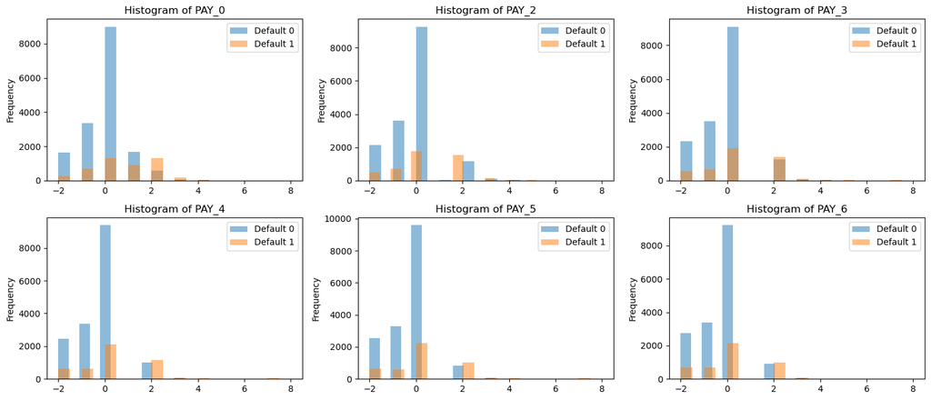

```python
fig, axes = plt.subplots(2, 3, figsize=(15, 6.5))

for i, feat in enumerate(['PAY_0','PAY_2', 'PAY_3', 'PAY_4', 'PAY_5', 'PAY_6']):
    row = i // 3
    col = i % 3
    # axes[row, col].hist(train_df[feat], bins=10, alpha=0.7)
    # axes[row, col].set_title(f'Distribution of {feat}')
    for name, group in train_df.groupby('default.payment.next.month'):
        group[feat].plot.hist(
            bins=20,
            alpha=0.5,
            ax=axes[row, col],
            label=f'Default {name}',  # 标记不同分组
            legend=True,
            title=f"Histogram of {feat}"
        )

plt.tight_layout()
plt.show()
```

Take a closer look at the LIMIT_BAL and BILL_AMT* columns:

```python
...
bill_amts = ['BILL_AMT1', 'BILL_AMT2', 'BILL_AMT3', 'BILL_AMT4', 'BILL_AMT5', 'BILL_AMT6']

pd.DataFrame({
    'BILL_AMT': bill_amts,
    'Negative_Diff_Counts': [(train_df['LIMIT_BAL'] - train_df[bill_amt] < 0).sum() for bill_amt in bill_amts]
})
```

|  | BILL_AMT | Negative_Diff_Counts |
| --- | --- | --- |
| 0 | BILL_AMT1 | 1486 |
| 1 | BILL_AMT2 | 1370 |
| 2 | BILL_AMT3 | 1121 |
| 3 | BILL_AMT4 | 738 |
| 4 | BILL_AMT5 | 604 |
| 5 | BILL_AMT6 | 564 |

We can see there are many observations whose amount of bill statement exceeds their amount of given credit. I think there would be some overdraft behaviors, so I will consider adding the interaction between LIMIT_BAL and BILL_AMT*.

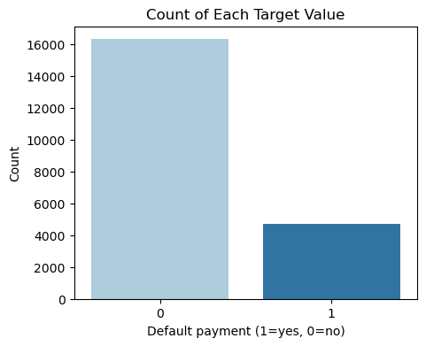

```python
...
plt.figure(figsize=(5,4))

sns.countplot(x='default.payment.next.month', data=train_df, palette='Paired')
plt.title('Count of Each Target Value')
plt.xlabel('Default payment (1=yes, 0=no)')
plt.ylabel('Count')
plt.show()
```

Here we see the data imbalance in our dataset: much more non-default clients than the default ones.

Our task is predicting whether a client will default or not. In the credit card repayment background, we would pay more attention to the default clients, so successfully identifying a client will default is more important than finding the one who will not default.

Therefore I will prioritize F1-score to ranking different models. In the following model evaluation part, I will use f1-score instead of accuracy.

## 4. Feature engineering

rubric={points:1}

**Your tasks:**

1. Carry out feature engineering. In other words, extract new features relevant for the problem and work with your new feature set in the following exercises. You may have to go back and forth between feature engineering and preprocessing.

Solution_4

*Points:* 1

### Bucketing numerical variables

I will first bucket the AGE column to divide it into several age groups for better pattern capturing:

```python
from sklearn.preprocessing import KBinsDiscretizer

discretization_transformer = KBinsDiscretizer(n_bins=6, encode="ordinal")
# will be used in the later preprocessing (transformation) part
```

### Feature interactions & feature crosses in LIMIT_BAL & BILL_AMT*

```python
from sklearn.preprocessing import PolynomialFeatures

poly = PolynomialFeatures(interaction_only=True, include_bias=False)
# will be used in the later preprocessing (transformation) part
```

## 5. Preprocessing and transformations

rubric={points:10}

**Your tasks:**

1. Identify different feature types and the transformations you would apply on each feature type.
2. Define a column transformer, if necessary.

Solution_5

*Points:* 10

First, I replace the "unknown" values with `NA` so that we can process them with tools like `SimpleImputer`

```python
...
X_train['EDUCATION'] = X_train['EDUCATION'].replace({0: np.nan, 5: np.nan, 6: np.nan})
X_train['MARRIAGE'] = X_train['MARRIAGE'].replace({0: np.nan, 3: np.nan})
```

Then I have missing values in columns EDUCTAION and MARRIAGE now, I will process them in the following steps.

### Identify feature types

```python
numeric_features = ['PAY_AMT1', 'PAY_AMT2', 'PAY_AMT3', 'PAY_AMT4', 'PAY_AMT5', 'PAY_AMT6']
interaction_features = ['LIMIT_BAL',
                        'BILL_AMT1', 'BILL_AMT2', 'BILL_AMT3', 'BILL_AMT4', 'BILL_AMT5', 'BILL_AMT6']
discretization_feats = ['AGE']
ordinal_features = ['EDUCATION',   # containing NA in EDUCATION
                    'PAY_0', 'PAY_2', 'PAY_3', 'PAY_4', 'PAY_5', 'PAY_6']
binary_features = ['MARRIAGE']  # containing NA
drop_features = ['SEX']
target = "default.payment.next.month"
```

```python
from sklearn.pipeline import make_pipeline
```

```python
from sklearn.base import BaseEstimator, TransformerMixin
class ReplaceValues(BaseEstimator, TransformerMixin):
    def __init__(self, replace_dict):
        self.replace_dict = replace_dict

    def fit(self, X, y=None):
        return self

    def transform(self, X):
        return X.replace(self.replace_dict)
# reference: https://towardsdatascience.com/customizing-scikit-learn-pipelines-write-your-own-transformer-fdaaefc5e5d7

# Create instances of transformers
replace_education = ReplaceValues({0: np.nan, 5: np.nan, 6: np.nan})
replace_marriage = ReplaceValues({0: np.nan, 3: np.nan})

### !!! i gave up using this cell: pass handle_unknown='ignore' to handle the unexpected values in future test set.
```

```python
...
# scaling for numerical
from sklearn.preprocessing import StandardScaler

numeric_transformer = StandardScaler()

numeric_transformer
```

```
StandardScaler()
```

```python
# interaction

interaction_transformer = make_pipeline(
    numeric_transformer,
    poly
)

interaction_transformer
```

```
Pipeline(steps=[('standardscaler', StandardScaler()),
                ('polynomialfeatures',
                 PolynomialFeatures(include_bias=False,
                                    interaction_only=True))])
```

```python
# discretization
discretization_transformer
# created in feature engineering section
```

```
KBinsDiscretizer(encode='ordinal', n_bins=6)
```

```python
...
# ordinal
from sklearn.preprocessing import OrdinalEncoder
from sklearn.impute import SimpleImputer

imputer = SimpleImputer(strategy='most_frequent')

ordinal_transformer = make_pipeline(
    imputer,
    OrdinalEncoder(handle_unknown='use_encoded_value', unknown_value=-1, dtype=int)
)

ordinal_transformer
```

```
Pipeline(steps=[('simpleimputer', SimpleImputer(strategy='most_frequent')),
                ('ordinalencoder',
                 OrdinalEncoder(dtype=<class 'int'>,
                                handle_unknown='use_encoded_value',
                                unknown_value=-1))])
```

```python
# binary
from sklearn.preprocessing import OneHotEncoder

binary_transformer = make_pipeline(
    imputer,
    OneHotEncoder(drop='if_binary', handle_unknown='ignore', dtype=int)
    )
binary_transformer
```

```
Pipeline(steps=[('simpleimputer', SimpleImputer(strategy='most_frequent')),
                ('onehotencoder',
                 OneHotEncoder(drop='if_binary', dtype=<class 'int'>,
                               handle_unknown='ignore'))])
```

### Creating the column transformer

```python
from sklearn.compose import make_column_transformer

preprocessor = make_column_transformer(
    (
        numeric_transformer, numeric_features
    ),
    (
        interaction_transformer, interaction_features
    ),
    (
        discretization_transformer, discretization_feats
    ),
    (
        ordinal_transformer, ordinal_features
    ),
    (
        binary_transformer, binary_features
    ),
    (
        'drop', drop_features
    )
)
```

## 6. Baseline model

rubric={points:2}

**Your tasks:**

1. Try `scikit-learn`'s baseline model and report results.

Solution_6

*Points:* 2

Using the dummy classifer as the baseline model

```python
...
from sklearn.dummy import DummyClassifier

dummy_clf_pipe = make_pipeline(preprocessor, DummyClassifier(random_state=123))
dummy_df = cross_validate(dummy_clf_pipe,
                          X_train, y_train,
                          cv=5,
                          return_train_score=True)
dummy_df=pd.DataFrame(dummy_df)

dummy_df
```

|  | fit_time | score_time | test_score | train_score |
| --- | --- | --- | --- | --- |
| 0 | 0.088003 | 0.021007 | 0.776905 | 0.776726 |
| 1 | 0.080004 | 0.018996 | 0.776905 | 0.776726 |
| 2 | 0.064001 | 0.018001 | 0.776667 | 0.776786 |
| 3 | 0.058000 | 0.014009 | 0.776667 | 0.776786 |
| 4 | 0.054003 | 0.014001 | 0.776667 | 0.776786 |

Take a look at the f1-score result of the dummy classifier

```python
dummy_df_f1 = cross_validate(dummy_clf_pipe,
                          X_train, y_train,
                          cv=5,
                          return_train_score=True,
                          scoring='f1')
dummy_df_f1=pd.DataFrame(dummy_df_f1)

dummy_df_f1
```

|  | fit_time | score_time | test_score | train_score |
| --- | --- | --- | --- | --- |
| 0 | 0.085296 | 0.017004 | 0.0 | 0.0 |
| 1 | 0.058001 | 0.015997 | 0.0 | 0.0 |
| 2 | 0.053037 | 0.017955 | 0.0 | 0.0 |
| 3 | 0.056000 | 0.016998 | 0.0 | 0.0 |
| 4 | 0.055002 | 0.015006 | 0.0 | 0.0 |

```python
...
# reference: hw3
results_dict = {}

def mean_std_cross_val_scores(model, X_train, y_train, **kwargs):
    """
    Returns mean and std of cross validation

    Parameters
    ----------
    model :
        scikit-learn model
    X_train : numpy array or pandas DataFrame
        X in the training data
    y_train :
        y in the training data

    Returns
    ----------
        pandas Series with mean scores from cross_validation
    """

    scores = cross_validate(model, X_train, y_train, **kwargs, scoring="f1")

    mean_scores = pd.DataFrame(scores).mean()
    std_scores = pd.DataFrame(scores).std()
    out_col = []

    for i in range(len(mean_scores)):
        out_col.append((f"%0.3f (+/- %0.3f)" % (mean_scores.iloc[i], std_scores.iloc[i])))

    return pd.Series(data=out_col, index=mean_scores.index)
```

```python
...
dummy_clf_pipe = make_pipeline(preprocessor, DummyClassifier(random_state=123))

results_dict["dummy"] = mean_std_cross_val_scores(
    dummy_clf_pipe, X_train, y_train, cv=5, return_train_score=True
)
results_df = pd.DataFrame(results_dict).T
results_df
```

|  | fit_time | score_time | test_score | train_score |
| --- | --- | --- | --- | --- |
| dummy | 0.056 (+/- 0.004) | 0.016 (+/- 0.001) | 0.000 (+/- 0.000) | 0.000 (+/- 0.000) |

## 7. Linear models

rubric={points:10}

**Your tasks:**

1. Try a linear model as a first real attempt.
2. Carry out hyperparameter tuning to explore different values for the complexity hyperparameter.
3. Report cross-validation scores along with standard deviation.
4. Summarize your results.

Solution_7

*Points:* 10

```python
...
from sklearn.linear_model import LogisticRegression

pipe_lr = make_pipeline(
    preprocessor,
    LogisticRegression(max_iter=1000, random_state=123),
)

lr_f1 = cross_validate(pipe_lr,
                          X_train, y_train,
                          cv=5,
                          return_train_score=True,
                          scoring='f1')
lr_f1=pd.DataFrame(lr_f1)

lr_f1
```

|  | fit_time | score_time | test_score | train_score |
| --- | --- | --- | --- | --- |
| 0 | 0.430366 | 0.021999 | 0.387833 | 0.387072 |
| 1 | 0.385995 | 0.019004 | 0.366436 | 0.380806 |
| 2 | 0.311998 | 0.018001 | 0.377504 | 0.370169 |
| 3 | 0.543998 | 0.020000 | 0.385671 | 0.368932 |
| 4 | 0.516997 | 0.020001 | 0.344498 | 0.380366 |

```python
results_dict["linear_model"] = mean_std_cross_val_scores(
    pipe_lr, X_train, y_train, cv=5, return_train_score=True
)
results_df = pd.DataFrame(results_dict).T
results_df
```

|  | fit_time | score_time | test_score | train_score |
| --- | --- | --- | --- | --- |
| dummy | 0.056 (+/- 0.004) | 0.016 (+/- 0.001) | 0.000 (+/- 0.000) | 0.000 (+/- 0.000) |
| linear_model | 0.322 (+/- 0.054) | 0.017 (+/- 0.002) | 0.372 (+/- 0.018) | 0.377 (+/- 0.008) |

Here we get the cross-validation scores with the mean of 0.372 and standard deviation of 0.018, which means the model performs stably across different validation sets, the score of 0.372 is reliable.

```python
...
# reference: lecture 08
best_score = 0

param_grid = {
    "C": [0.001, 0.01, 0.1, 1, 10, 100],
    'max_iter': [500, 1000, 1500],
}

results_dict_hyperpara = {"C": [], "max_iter": [], "mean_cv_score": []}

for max_iter in param_grid["max_iter"]:
    for C in param_grid["C"]:  # for each combination of parameters, train an SVC
        pipe_lr = make_pipeline(preprocessor, LogisticRegression(max_iter=max_iter, C=C))
        scores = cross_val_score(pipe_lr, X_train, y_train, scoring='f1')  # perform cross-validation
        mean_score = np.mean(scores)  # compute mean cross-validation accuracy
        if (
            mean_score > best_score
        ):  # if we got a better score, store the score and parameters
            best_score = mean_score
            best_parameters = {"C": C, "max_iter": max_iter}
        results_dict_hyperpara["C"].append(C)
        results_dict_hyperpara["max_iter"].append(max_iter)
        results_dict_hyperpara["mean_cv_score"].append(mean_score)
```

```python
...
best_parameters
```

```
{'C': 100, 'max_iter': 500}
```

```python
...
best_score
```

```
0.3726546285817249
```

```python
df = pd.DataFrame(results_dict_hyperpara)
df.sort_values(by="mean_cv_score", ascending=False).head(10)
```

|  | C | max_iter | mean_cv_score |
| --- | --- | --- | --- |
| 17 | 100.0 | 1500 | 0.372655 |
| 5 | 100.0 | 500 | 0.372655 |
| 11 | 100.0 | 1000 | 0.372655 |
| 15 | 1.0 | 1500 | 0.372388 |
| 9 | 1.0 | 1000 | 0.372388 |
| 3 | 1.0 | 500 | 0.372388 |
| 4 | 10.0 | 500 | 0.372233 |
| 10 | 10.0 | 1000 | 0.372233 |
| 16 | 10.0 | 1500 | 0.372233 |
| 8 | 0.1 | 1000 | 0.369396 |

**Summary**

With the linear model, the f1-score increases by 37% from the baseline model. The f1-scores do not vary much across different validation sets, which is good and indicates the model is reliable. The f1-scores across different values of hyperparameters do not change a lot: it may be caused by the inappropriate ranges chosen of the hyperparameters.

## 8. Different models

rubric={points:12}

**Your tasks:**

1. Try at least 3 other models aside from a linear model. One of these models should be a tree-based ensemble model.
2. Summarize your results in terms of overfitting/underfitting and fit and score times. Can you beat a linear model?

Solution_8

*Points:* 12

#### model1: random forests classifier

```python
...
from sklearn.ensemble import RandomForestClassifier

pipe_rf = make_pipeline(
    preprocessor,
    RandomForestClassifier(max_depth=6, n_estimators=7, random_state=123)
)

results_dict["random_forest"] = mean_std_cross_val_scores(
    pipe_rf, X_train, y_train, cv=5, return_train_score=True
)
results_df = pd.DataFrame(results_dict).T
results_df
```

|  | fit_time | score_time | test_score | train_score |
| --- | --- | --- | --- | --- |
| dummy | 0.056 (+/- 0.004) | 0.016 (+/- 0.001) | 0.000 (+/- 0.000) | 0.000 (+/- 0.000) |
| linear_model | 0.322 (+/- 0.054) | 0.017 (+/- 0.002) | 0.372 (+/- 0.018) | 0.377 (+/- 0.008) |
| random_forest | 0.422 (+/- 0.030) | 0.020 (+/- 0.002) | 0.447 (+/- 0.016) | 0.483 (+/- 0.009) |

#### model2: K-NN classifier

```python
...
from sklearn.neighbors import KNeighborsClassifier

pipe_knn = make_pipeline(
    preprocessor,
    KNeighborsClassifier(n_neighbors=45)
)

results_dict["knn"] = mean_std_cross_val_scores(
    pipe_knn, X_train, y_train, cv=5, return_train_score=True
)
results_df = pd.DataFrame(results_dict).T
results_df
```

|  | fit_time | score_time | test_score | train_score |
| --- | --- | --- | --- | --- |
| dummy | 0.056 (+/- 0.004) | 0.016 (+/- 0.001) | 0.000 (+/- 0.000) | 0.000 (+/- 0.000) |
| linear_model | 0.322 (+/- 0.054) | 0.017 (+/- 0.002) | 0.372 (+/- 0.018) | 0.377 (+/- 0.008) |
| random_forest | 0.422 (+/- 0.030) | 0.020 (+/- 0.002) | 0.447 (+/- 0.016) | 0.483 (+/- 0.009) |
| knn | 0.080 (+/- 0.012) | 0.324 (+/- 0.101) | 0.421 (+/- 0.016) | 0.433 (+/- 0.006) |

#### model3: SVM RBF

```python
...
from sklearn.svm import SVC

pipe_svm = make_pipeline(
    preprocessor,
    SVC(gamma=0.1, C=10)
)

X_sample = X_train.sample(frac=0.3, random_state=123)  # Use 30% of the data
y_sample = y_train[X_sample.index]

results_dict["svm_rbf_sample"] = mean_std_cross_val_scores(
    pipe_svm, X_sample, y_sample, cv=5, return_train_score=True
)
results_df = pd.DataFrame(results_dict).T
results_df
```

|  | fit_time | score_time | test_score | train_score |
| --- | --- | --- | --- | --- |
| dummy | 0.056 (+/- 0.004) | 0.016 (+/- 0.001) | 0.000 (+/- 0.000) | 0.000 (+/- 0.000) |
| linear_model | 0.322 (+/- 0.054) | 0.017 (+/- 0.002) | 0.372 (+/- 0.018) | 0.377 (+/- 0.008) |
| random_forest | 0.422 (+/- 0.030) | 0.020 (+/- 0.002) | 0.447 (+/- 0.016) | 0.483 (+/- 0.009) |
| knn | 0.080 (+/- 0.012) | 0.324 (+/- 0.101) | 0.421 (+/- 0.016) | 0.433 (+/- 0.006) |
| svm_rbf_sample | 1.342 (+/- 0.118) | 0.354 (+/- 0.034) | 0.395 (+/- 0.012) | 0.762 (+/- 0.008) |

**Summary**

DummyClassifier as our baseline model works the most fast throughout fitting and scoring, but its f1-score are extremely bad in this dataset. Except the baseline, we can see the random forests model get the highest mean score, beat the linear model, in the validation sets with slight overfitting, and its fit and score times are relatively short; k-NN classifier also performs well with slight overfitting and lower fit time but higher score time; linear model (logistic model) works worst here but it is much less overfitting and run fast; svm rbf model shows really long run time and very high overfitting on this dataset (sample, since the model is too slow to run on the whole training set and see the results).

I would acknowledge that I have not carefully tuned hyperparameters of these models, so they would be some difference in the conclusion here when changing some hyperparameter values.

## 9. Feature selection

rubric={points:2}

**Your tasks:**

Make some attempts to select relevant features. You may try `RFECV` or forward selection for this. Do the results improve with feature selection? Summarize your results. If you see improvements in the results, keep feature selection in your pipeline. If not, you may abandon it in the next exercises.

Solution_9

*Points:* 2

```python
...
from sklearn.feature_selection import RFECV

rfe_pipe = make_pipeline(
    preprocessor,
    RFECV(LogisticRegression(max_iter=2000), cv=5),
    RandomForestClassifier(n_estimators=100, random_state=123),
)

results_dict["rf_rfe"] = mean_std_cross_val_scores(
    rfe_pipe, X_train, y_train, cv=5, return_train_score=True
)
results_df = pd.DataFrame(results_dict).T
results_df
```

|  | fit_time | score_time | test_score | train_score |
| --- | --- | --- | --- | --- |
| dummy | 0.056 (+/- 0.004) | 0.016 (+/- 0.001) | 0.000 (+/- 0.000) | 0.000 (+/- 0.000) |
| linear_model | 0.322 (+/- 0.054) | 0.017 (+/- 0.002) | 0.372 (+/- 0.018) | 0.377 (+/- 0.008) |
| random_forest | 0.422 (+/- 0.030) | 0.020 (+/- 0.002) | 0.447 (+/- 0.016) | 0.483 (+/- 0.009) |
| knn | 0.080 (+/- 0.012) | 0.324 (+/- 0.101) | 0.421 (+/- 0.016) | 0.433 (+/- 0.006) |
| svm_rbf_sample | 1.342 (+/- 0.118) | 0.354 (+/- 0.034) | 0.395 (+/- 0.012) | 0.762 (+/- 0.008) |
| rf_rfe | 24.880 (+/- 1.591) | 0.022 (+/- 0.001) | 0.442 (+/- 0.017) | 0.444 (+/- 0.005) |

With the results, we can find the performance of random forest model with feature selection does not really improve a lot: the f1-score of the one with RFE does not increase although it is less overfitting than the original one, plus its very long run-time, I do not think it improves a lot with feature selection and I will not include feature selection in my pipeline.

```python
...
```

```
Ellipsis
```

## 10. Hyperparameter optimization

rubric={points:10}

**Your tasks:**

Make some attempts to optimize hyperparameters for the models you've tried and summarize your results. In at least one case you should be optimizing multiple hyperparameters for a single model. You may use `sklearn`'s methods for hyperparameter optimization or fancier Bayesian optimization methods.

- [GridSearchCV](http://scikit-learn.org/stable/modules/generated/sklearn.model_selection.GridSearchCV.html)
- [RandomizedSearchCV](http://scikit-learn.org/stable/modules/generated/sklearn.model_selection.RandomizedSearchCV.html)
- scikit-optimize

Solution_10

*Points:* 10

I will use RandomizedSearchCV to tune the hyperparameters:

```python
...
from sklearn.ensemble import RandomForestClassifier
from sklearn.model_selection import RandomizedSearchCV
from scipy.stats import randint

param_dist = {
    'randomforestclassifier__n_estimators': randint(1, 30),
    'randomforestclassifier__max_depth': [None, 5, 10, 20, 30, 40],
}

rf_tuning = make_pipeline(
    preprocessor,
    RandomForestClassifier(random_state=123)
)

random_search = RandomizedSearchCV(rf_tuning,
    param_distributions=param_dist,
    n_iter=50,
    cv=3,
    scoring='f1',
    random_state=123,
    n_jobs=-1
)
random_search.fit(X_train, y_train)
```

```
RandomizedSearchCV(cv=3,
                   estimator=Pipeline(steps=[('columntransformer',
                                              ColumnTransformer(transformers=[('standardscaler',
                                                                               StandardScaler(),
                                                                               ['PAY_AMT1',
                                                                                'PAY_AMT2',
                                                                                'PAY_AMT3',
                                                                                'PAY_AMT4',
                                                                                'PAY_AMT5',
                                                                                'PAY_AMT6']),
                                                                              ('pipeline-1',
                                                                               Pipeline(steps=[('standardscaler',
                                                                                                StandardScaler()),
                                                                                               ('polynomialfeatures',
                                                                                                PolynomialFeatures(include_bias=False,
                                                                                                                   interaction_only=...
                                                                               ['MARRIAGE']),
                                                                              ('drop',
                                                                               'drop',
                                                                               ['SEX'])])),
                                             ('randomforestclassifier',
                                              RandomForestClassifier(random_state=123))]),
                   n_iter=50, n_jobs=-1,
                   param_distributions={'randomforestclassifier__max_depth': [None,
                                                                              5,
                                                                              10,
                                                                              20,
                                                                              30,
                                                                              40],
                                        'randomforestclassifier__n_estimators': <scipy.stats._distn_infrastructure.rv_discrete_frozen object at 0x000001ABD5F8A390>},
                   random_state=123, scoring='f1')
```

```python
...
random_search.best_score_
```

```
0.45658828832749254
```

```python
...
pd.DataFrame(random_search.cv_results_)[
    [
        "mean_test_score",
        'param_randomforestclassifier__n_estimators',
        'param_randomforestclassifier__max_depth',
        "mean_fit_time",
        "rank_test_score",
    ]
].set_index("rank_test_score").sort_index().T
```

| rank_test_score | 1 | 2 | 3 | 4 | 5 | 6 | 7 | 8 | 9 | 10 | 11 | 11 | 13 | 13 | 15 | 16 | 17 | 18 | 19 | 20 | 21 | 21 | 23 | 24 | 25 | 26 | 27 | 28 | 29 | … |
| --- | --- | --- | --- | --- | --- | --- | --- | --- | --- | --- | --- | --- | --- | --- | --- | --- | --- | --- | --- | --- | --- | --- | --- | --- | --- | --- | --- | --- | --- | --- |
| mean_test_score | 0.456588 | 0.454847 | 0.454441 | 0.453139 | 0.452763 | 0.452098 | 0.451186 | 0.450121 | 0.449512 | 0.448957 | 0.448392 | 0.448392 | 0.445004 | 0.445004 | 0.443954 | 0.442174 | 0.441553 | 0.436773 | 0.433098 | 0.432194 | 0.430621 | 0.430621 | 0.428005 | 0.42742 | 0.422289 | 0.419269 | 0.416865 | 0.416135 | 0.406185 | … |
| param_randomforestclassifier__n_estimators | 29 | 23 | 28 | 27 | 21 | 25 | 17 | 19 | 18 | 23 | 6 | 6 | 17 | 17 | 28 | 28 | 13 | 22 | 22 | 20 | 7 | 7 | 18 | 16 | 5 | 16 | 4 | 12 | 3 | … |
| param_randomforestclassifier__max_depth | 30 | 10 | 10 | 10 | 10 | 30 | 10 | 40 | 10 | 20 | 10 | 10 | None | None | None | 20 | 40 | 20 | 30 | 40 | 30 | 30 | 30 | None | 40 | 30 | 5 | None | 40 | … |
| mean_fit_time | 6.674431 | 3.438444 | 4.383778 | 4.008828 | 3.116212 | 6.046989 | 2.623676 | 4.614787 | 2.802916 | 5.368052 | 1.118592 | 1.0233 | 4.096258 | 4.101884 | 5.276284 | 6.193887 | 3.071771 | 3.663161 | 5.098605 | 4.713413 | 1.730459 | 1.674265 | 4.145485 | 3.981316 | 1.439646 | 3.721029 | 0.464091 | 3.079324 | 0.966131 | … |

Now in the preliminary tuning we get the best score of 0.4566 with n_estimators=29 and max_depth=30; let me further tune the hyperparameterts in other intervals of values:

```python
...
param_dist_1 = {
    'randomforestclassifier__n_estimators': randint(35, 50),
    'randomforestclassifier__max_depth': randint(20, 50),
}

random_search_1 = RandomizedSearchCV(rf_tuning,
    param_distributions=param_dist_1,
    n_iter=50,
    cv=3,
    scoring='f1',
    random_state=123,
    n_jobs=-1
)
random_search_1.fit(X_train, y_train)
print(random_search_1.best_score_)
pd.DataFrame(random_search_1.cv_results_)[
    [
        "mean_test_score",
        'param_randomforestclassifier__n_estimators',
        'param_randomforestclassifier__max_depth',
        "mean_fit_time",
        "rank_test_score",
    ]
].set_index("rank_test_score").sort_index().T
```

```
0.4651262132652397
```

| rank_test_score | 1 | 2 | 3 | 4 | 5 | 6 | 7 | 8 | 9 | 10 | 11 | 12 | 13 | 14 | 15 | 16 | 16 | 18 | 19 | 20 | 21 | 22 | 23 | 24 | 25 | 25 | 27 | 28 | 29 | … |
| --- | --- | --- | --- | --- | --- | --- | --- | --- | --- | --- | --- | --- | --- | --- | --- | --- | --- | --- | --- | --- | --- | --- | --- | --- | --- | --- | --- | --- | --- | --- |
| mean_test_score | 0.465126 | 0.463921 | 0.463516 | 0.462967 | 0.462733 | 0.462101 | 0.461865 | 0.461708 | 0.461614 | 0.461436 | 0.461270 | 0.461022 | 0.460872 | 0.460868 | 0.460508 | 0.459008 | 0.459008 | 0.458990 | 0.458856 | 0.458672 | 0.458582 | 0.458343 | 0.458166 | 0.457982 | 0.457870 | 0.45787 | 0.457635 | 0.456794 | 0.456518 | … |
| param_randomforestclassifier__n_estimators | 49.000000 | 37.000000 | 45.000000 | 47.000000 | 35.000000 | 47.000000 | 49.000000 | 47.000000 | 47.000000 | 41.000000 | 39.000000 | 41.000000 | 39.000000 | 39.000000 | 49.000000 | 43.000000 | 43.000000 | 49.000000 | 41.000000 | 41.000000 | 37.000000 | 37.000000 | 49.000000 | 37.000000 | 35.000000 | 35.00000 | 38.000000 | 44.000000 | 49.000000 | … |
| param_randomforestclassifier__max_depth | 26.000000 | 27.000000 | 22.000000 | 22.000000 | 21.000000 | 21.000000 | 33.000000 | 23.000000 | 37.000000 | 45.000000 | 48.000000 | 41.000000 | 22.000000 | 49.000000 | 37.000000 | 40.000000 | 40.000000 | 32.000000 | 22.000000 | 40.000000 | 33.000000 | 45.000000 | 20.000000 | 47.000000 | 46.000000 | 49.00000 | 21.000000 | 20.000000 | 39.000000 | … |
| mean_fit_time | 11.607658 | 8.251890 | 10.383114 | 10.865672 | 7.902768 | 10.834893 | 11.823313 | 10.307489 | 10.594298 | 9.583983 | 8.831101 | 9.586547 | 8.279463 | 8.952174 | 11.440469 | 10.146394 | 9.941014 | 11.716861 | 9.607311 | 9.923703 | 8.781805 | 8.911123 | 10.494705 | 8.741188 | 8.333947 | 8.14164 | 6.227804 | 9.675196 | 11.638409 | … |

Here I get the best score of 0.4651 with n_estimators=49 and max_depth=26. I also tried larger values in both hyperparameters but scores go down when I increase them. Therefore, I will use n_estimators=49 and max_depth=26 in my final model.

Update our random forest model:

```python
...
pipe_rf_best_param = make_pipeline(
    preprocessor,
    RandomForestClassifier(max_depth=26, n_estimators=49, random_state=123)
)

results_dict["random_forest_best_param"] = mean_std_cross_val_scores(
    pipe_rf_best_param, X_train, y_train, cv=5, return_train_score=True
)
results_df = pd.DataFrame(results_dict).T
results_df
```

|  | fit_time | score_time | test_score | train_score |
| --- | --- | --- | --- | --- |
| dummy | 0.056 (+/- 0.004) | 0.016 (+/- 0.001) | 0.000 (+/- 0.000) | 0.000 (+/- 0.000) |
| linear_model | 0.322 (+/- 0.054) | 0.017 (+/- 0.002) | 0.372 (+/- 0.018) | 0.377 (+/- 0.008) |
| random_forest | 0.422 (+/- 0.030) | 0.020 (+/- 0.002) | 0.447 (+/- 0.016) | 0.483 (+/- 0.009) |
| knn | 0.080 (+/- 0.012) | 0.324 (+/- 0.101) | 0.421 (+/- 0.016) | 0.433 (+/- 0.006) |
| svm_rbf_sample | 1.342 (+/- 0.118) | 0.354 (+/- 0.034) | 0.395 (+/- 0.012) | 0.762 (+/- 0.008) |
| rf_rfe | 24.880 (+/- 1.591) | 0.022 (+/- 0.001) | 0.442 (+/- 0.017) | 0.444 (+/- 0.005) |
| random_forest_best_param | 4.181 (+/- 0.205) | 0.040 (+/- 0.001) | 0.459 (+/- 0.010) | 0.982 (+/- 0.001) |

## 11. Interpretation and feature importances

rubric={points:10}

**Your tasks:**

1. Use the methods we saw in class (e.g., `shap`) (or any other methods of your choice) to examine the most important features of one of the non-linear models.
2. Summarize your observations.

Solution_11

*Points:* 10

```python
...
import shap

rf_model = pipe_rf_best_param.named_steps["randomforestclassifier"]
rf_model.fit(X_train, y_train)

explainer = shap.TreeExplainer(rf_model) # define the shap explainer
```

```python
...
preprocessor.fit(X_train, y_train)

feature_names = preprocessor.get_feature_names_out()

X_test_enc = pd.DataFrame(
    data=preprocessor.transform(X_test),
    columns=feature_names,
    index=X_test.index,
)

shap_values = explainer(X_test_enc)
```

```python
...
shap.initjs()
```

have a look at our shap values:

```python
print(f"SHAP values shape: {shap_values.shape}")
print(f"Encoded test data shape: {X_test_enc.shape}")
```

```
SHAP values shape: (9000, 43, 2)
Encoded test data shape: (9000, 43)
```

```python
shap_values
```

[output not shown]

[output cut: 19 more lines]

[output not shown]

After looking up some materials, I know 2 in (9000, 43, 2) indicates the output classes (typically for binary classification, the SHAP values will return an array of shape (n_samples, n_features, n_classes), where n_classes is the number of classes). In a binary classification model, SHAP may return SHAP values for both classes, hence the third dimension is 2.

Value 1 (yes) of our target (Default payment) represents the positive class, so I select SHAP values for a this positive class:

```python
shap_values_positive_class = shap_values[:, :, 1]
```

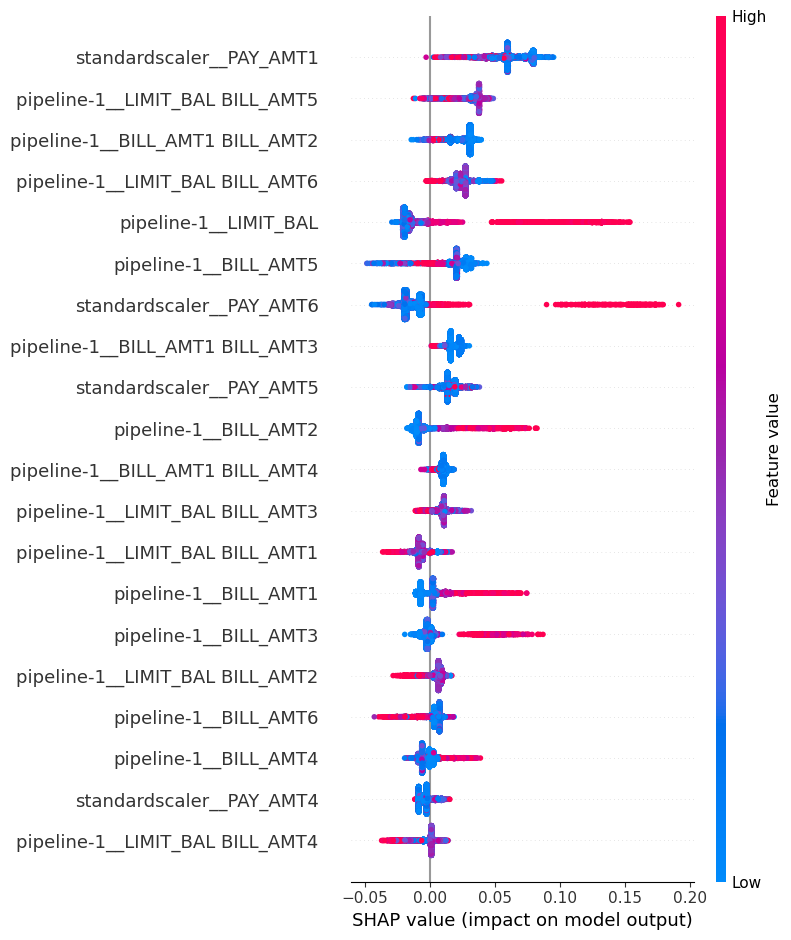

```python
...
shap.summary_plot(shap_values_positive_class, X_test_enc)
```

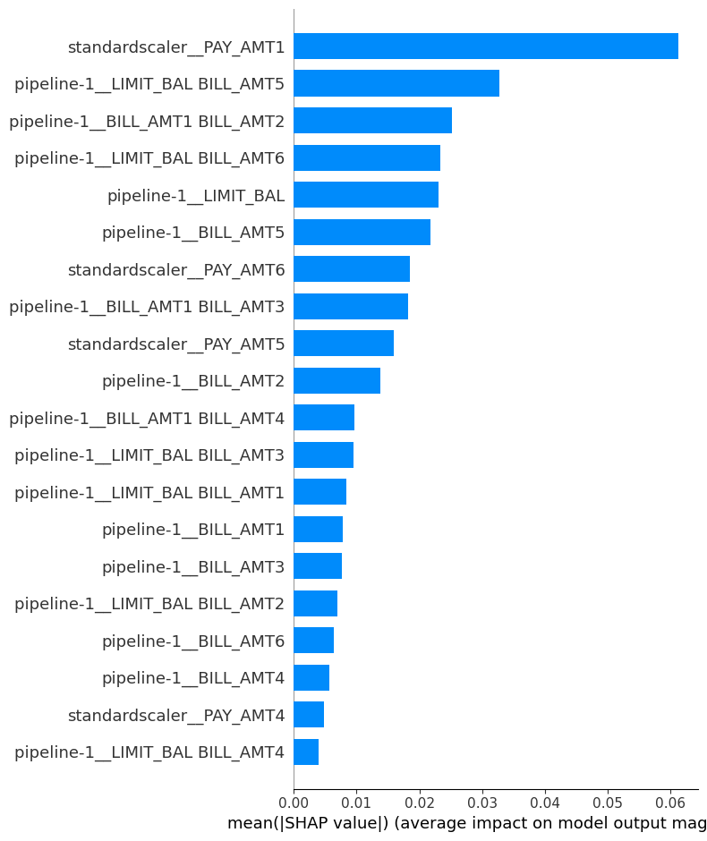

```python
...
shap.summary_plot(shap_values_positive_class, X_test_enc, plot_type="bar")
```

Here I find the scaled `PAY_AMT1` contributes a lot on identifying the default clients than other features, with roughly lower values of it indicating defaulted clients. Also, some of the interaction between `BILL_AMT*` and `LIMIT_BAL` work well on detecting defaults. `LIMIT_BAL` also work well individually on the prediction, with higher values indicating more on default behaviors.

However, there are some feature in the interaction between `BILL_AMT*` and `LIMIT_BAL` not really helping a lot for predicting default, such as the interaction between `LIMIT_BAL` and `BILL_AMT4`. Therefore, there are some different performance of payment amount on the prediction across different months, having different levels of importance.

```python
...
```

```
Ellipsis
```

## 12. Results on the test set

rubric={points:10}

**Your tasks:**

1. Try your best performing model on the test data and report test scores.
2. Do the test scores agree with the validation scores from before? To what extent do you trust your results? Do you think you've had issues with optimization bias?
3. Take one or two test predictions and explain these individual predictions (e.g., with SHAP force plots).

Solution_12

*Points:* 10

```python
...
from sklearn.metrics import accuracy_score, f1_score, precision_score, recall_score, roc_auc_score, classification_report

pipe_rf_best_param.fit(X_train, y_train)

y_pred = pipe_rf_best_param.predict(X_test)
y_pred_proba = pipe_rf_best_param.predict_proba(X_test)[:, 1]
```

```python
...
accuracy = accuracy_score(y_test, y_pred)
f1 = f1_score(y_test, y_pred)
precision = precision_score(y_test, y_pred)
recall = recall_score(y_test, y_pred)
auc = roc_auc_score(y_test, y_pred_proba)
```

```python
...
results = {
    'Metric': ['Accuracy', 'F1 Score', 'Precision', 'Recall', 'AUC'],
    'Score': [accuracy, f1, precision, recall, auc]
}

results_rf = pd.DataFrame(results)

print(results_rf)
```

```
      Metric     Score
0   Accuracy  0.811333
1   F1 Score  0.463338
2  Precision  0.602796
3     Recall  0.376283
4        AUC  0.755118
```

Here I get the F1 score of 0.463338 on the test data.

The test scores do agree with the validation scores from before. I relatively trust my results even if the test one is even higher than the validation one, since the gap is not so large and it might be caused by luck, as well as my low standard deviation values of the validtaion scores.

I do not think I encounter optimization bias with a even better score on the test data. There might be overfitting here with the really high training scores, but optimization part has no big issures.

#### Take one test prediction:

```python
ex1_idx = 10
X_test_enc.iloc[ex1_idx]
```

```
standardscaler__PAY_AMT1          -0.274387
standardscaler__PAY_AMT2          -0.085319
standardscaler__PAY_AMT3          -0.234603
standardscaler__PAY_AMT4          -0.218613
standardscaler__PAY_AMT5          -0.128177
standardscaler__PAY_AMT6          -0.289117
pipeline-1__LIMIT_BAL             -0.905384
pipeline-1__BILL_AMT1             -0.069491
pipeline-1__BILL_AMT2             -0.044130
pipeline-1__BILL_AMT3              0.028140
pipeline-1__BILL_AMT4              0.082730
pipeline-1__BILL_AMT5              0.145287
pipeline-1__BILL_AMT6              0.207695
pipeline-1__LIMIT_BAL BILL_AMT1    0.062916
pipeline-1__LIMIT_BAL BILL_AMT2    0.039955
pipeline-1__LIMIT_BAL BILL_AMT3   -0.025477
pipeline-1__LIMIT_BAL BILL_AMT4   -0.074903
pipeline-1__LIMIT_BAL BILL_AMT5   -0.131540
pipeline-1__LIMIT_BAL BILL_AMT6   -0.188044
pipeline-1__BILL_AMT1 BILL_AMT2    0.003067
pipeline-1__BILL_AMT1 BILL_AMT3   -0.001955
pipeline-1__BILL_AMT1 BILL_AMT4   -0.005749
pipeline-1__BILL_AMT1 BILL_AMT5   -0.010096
pipeline-1__BILL_AMT1 BILL_AMT6   -0.014433
pipeline-1__BILL_AMT2 BILL_AMT3   -0.001242
pipeline-1__BILL_AMT2 BILL_AMT4   -0.003651
pipeline-1__BILL_AMT2 BILL_AMT5   -0.006412
pipeline-1__BILL_AMT2 BILL_AMT6   -0.009166
pipeline-1__BILL_AMT3 BILL_AMT4    0.002328
pipeline-1__BILL_AMT3 BILL_AMT5    0.004088
pipeline-1__BILL_AMT3 BILL_AMT6    0.005844
pipeline-1__BILL_AMT4 BILL_AMT5    0.012020
pipeline-1__BILL_AMT4 BILL_AMT6    0.017183
pipeline-1__BILL_AMT5 BILL_AMT6    0.030175
kbinsdiscretizer__AGE              3.000000
pipeline-2__EDUCATION              2.000000
pipeline-2__PAY_0                  4.000000
pipeline-2__PAY_2                  4.000000
pipeline-2__PAY_3                  4.000000
pipeline-2__PAY_4                  5.000000
pipeline-2__PAY_5                  3.000000
pipeline-2__PAY_6                  3.000000
pipeline-3__MARRIAGE_2.0           1.000000
Name: 121, dtype: float64
```

```python
y_test.iloc[ex1_idx]
```

```
1
```

```python
y_pred[ex1_idx]
```

```
1
```

```python
y_pred_proba[ex1_idx]
```

```
0.6303339517625232
```

Here I've tried to use the `shap.force_plot()` function to draw the SHAP force plots for the individual observation I assigned above, but there is a TypeError saying that "In v0.20, force plot now requires the base value as the first parameter! Try shap.plots.force(explainer.expected_value, shap_values) or for multi-output models try shap.plots.force(explainer.expected_value[0], shap_values[..., 0])."

I've also tried to follow the instruction to try the code it provides and tried to downgrade the version of the package `shap`, but neither works. (I even posted a question on the piazza! but no one answered and helped me, so I just comment out the code here)

```python
...
# shap.force_plot(explainer.expected_value, shap_values.values[ex1_idx, :], X_test_enc.iloc[ex1_idx, :])
```

```
Ellipsis
```

```python
...
```

```
Ellipsis
```

## 13. Summary of results

rubric={points:12}

Imagine that you want to present the summary of these results to your boss and co-workers.

**Your tasks:**

1. Create a table summarizing important results.
2. Write concluding remarks.
3. Discuss other ideas that you did not try but could potentially improve the performance/interpretability .
4. Report your final test score along with the metric you used at the top of this notebook in the Submission instructions section.

Solution_13

*Points:* 12

Results of F1-score for different models:

```python
...
results_df
```

|  | fit_time | score_time | test_score | train_score |
| --- | --- | --- | --- | --- |
| dummy | 0.056 (+/- 0.004) | 0.016 (+/- 0.001) | 0.000 (+/- 0.000) | 0.000 (+/- 0.000) |
| linear_model | 0.322 (+/- 0.054) | 0.017 (+/- 0.002) | 0.372 (+/- 0.018) | 0.377 (+/- 0.008) |
| random_forest | 0.422 (+/- 0.030) | 0.020 (+/- 0.002) | 0.447 (+/- 0.016) | 0.483 (+/- 0.009) |
| knn | 0.080 (+/- 0.012) | 0.324 (+/- 0.101) | 0.421 (+/- 0.016) | 0.433 (+/- 0.006) |
| svm_rbf_sample | 1.342 (+/- 0.118) | 0.354 (+/- 0.034) | 0.395 (+/- 0.012) | 0.762 (+/- 0.008) |
| rf_rfe | 24.880 (+/- 1.591) | 0.022 (+/- 0.001) | 0.442 (+/- 0.017) | 0.444 (+/- 0.005) |
| random_forest_best_param | 4.181 (+/- 0.205) | 0.040 (+/- 0.001) | 0.459 (+/- 0.010) | 0.982 (+/- 0.001) |

Results of different metrics for our final random forest model:

```python
...
results_rf
```

|  | Metric | Score |
| --- | --- | --- |
| 0 | Accuracy | 0.811333 |
| 1 | F1 Score | 0.463338 |
| 2 | Precision | 0.602796 |
| 3 | Recall | 0.376283 |
| 4 | AUC | 0.755118 |

The credit default prediction problem revealed the performance of different machine learning models. The Random Forest model outperformed others like k-NN classifier, svm rbf, and logistical regression with an F1-score of 0.447（0.459 after hyperparameter tuning, 0.4633 on test data）and an AUC of 0.7551, indicating its robustness in identifying clients as potential defaulters.

My model here has a slightly higher final test score than its mean validation score. This could be luck, but with its low standard deviation of 0.010 in the validation scores, I would say the results would be reliable to be applied on the future unseen data.

The model's feature importance analysis highlighted key predictors, such as payment amounts and limit balances, which are crucial for decision-making in credit assessment.

Other ideas:

1. I am considering creating a new feature called repayment rate by deviding the payment amount in each month by the amount of bill statement in each month, and I think there may be strong relationship between the repayment rate in each month and the default behavior, which could help us to make prediction. However, creating this new column needs us to drop the original columns used to calculate it in order to avoid multicollinearity, but the feature importance section has shown us that the `PAY_AMT1` column contributes a lot to our prediction, and the interaction between `LIMIT_BILL` and `BILL_AMT*` follows up. If we just drop the columns, our model performance might work worse. This would need further comparison in different models, which might perform better than my final model here.
2. I must acknowledge that in the process of training and selecting different models, I reduced some values of some hyperparameters such as the number of folds for cross-validation and the value of `n_estimator=` argument, just to save time. If there is a higher time budget, there might be a better perforance from a better model. For sure, a faster performance itself never be bad.

My final random forest model has an f1-score of 0.463338.

## 14. Your takeaway

rubric={points:2}

**Your tasks:**

What is your biggest takeaway from the supervised machine learning material we have learned so far? Please write thoughtful answers.

Solution_14

*Points:* 2

My biggest takeway from the supervised machine learning material is that the quality of data really matters in our model building process. A good data information would be much useful than a good machine learning model. Therefore, the preprocessing and feature engineering are quite crucial to our modeling. Also high accuracy is not always insightful for a prediction problem. There are many useful evaluation metrics we can use for more targeted prediction tasks.

**PLEASE READ BEFORE YOU SUBMIT:**

When you are ready to submit your assignment do the following:

1. Run all cells in your notebook to make sure there are no errors by doing `Kernel -> Restart Kernel and Clear All Outputs` and then `Run -> Run All Cells`.
2. Notebooks with cell execution numbers out of order or not starting from "1" will have marks deducted. Notebooks without the output displayed may not be graded at all (because we need to see the output in order to grade your work).
3. Upload the assignment using Gradescope's drag and drop tool. Check out this [Gradescope Student Guide](https://lthub.ubc.ca/guides/gradescope-student-guide/) if you need help with Gradescope submission.
4. Make sure that the plots and output are rendered properly in your submitted file. If the .ipynb file is too big and doesn't render on Gradescope, also upload a pdf or html in addition to the .ipynb so that the TAs can view your submission on Gradescope.

This was a tricky one but you did it!

[figure not shown]